# Homework4

Noah Mott

2/14/2021

##Loading the necessary libraries etc.

```r
#install.packages('data.table')
library(wordcloud2)
library(wordcloud)
library(slam)
library(quanteda)
library(SnowballC)
library(arules)
library(proxy)
library(cluster)
library(stringi)
library(Matrix)
library(tidytext)
library(plyr)
library(ggplot2)
library(factoextra)
library(mclust)
library(dplyr)
library(tm)
library(ggplot2)
library(dplyr)
library(gridExtra)
library(ggforce)
library(grid)
library(data.table)
```

#Load in the Data

```r
papers<-read.csv('C:/Users/noahm/OneDrive/Desktop/fedPapers85.csv')
paperscopy<-papers
```

#Format Data for use in kmeans clustering

```r
paperskmeans<-paperscopy[,2:72]
rownames(paperskmeans)<-paperskmeans[,1]
paperskmeans[,1]<-NULL
```

#Conduct initial analysis of the data to determine ideal number of clusters

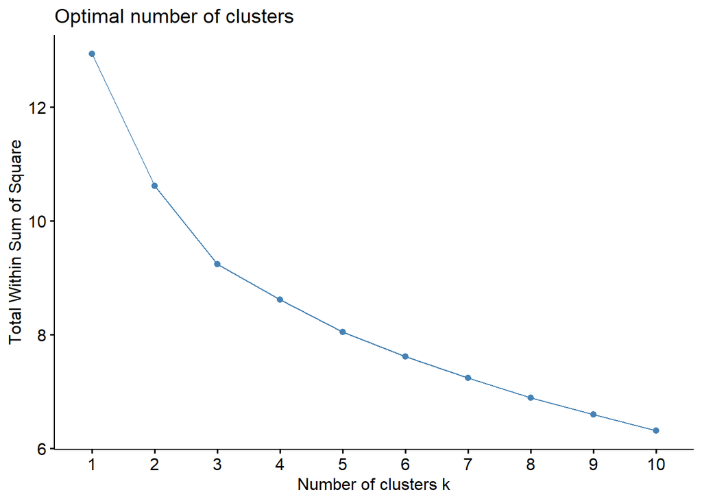

```r
fviz_nbclust(papers, FUN=hcut, method = 'wss')
```

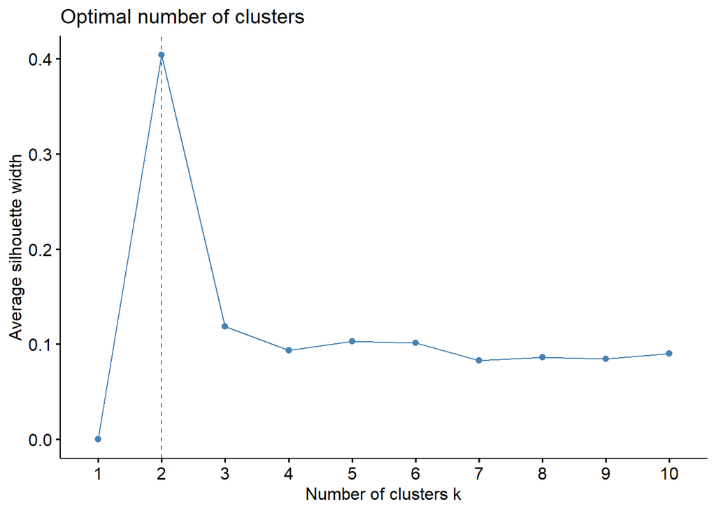

```r
fviz_nbclust(papers, FUN=hcut, method='silhouette')
```

#initial value fell short. Chose 7 clusters for future use based on assessment of the data.

```r
clusters<-kmeans(paperskmeans, 7)
paperskmeans$Clusters<-as.factor(clusters$cluster)
```

#additional visual exploration of the Data

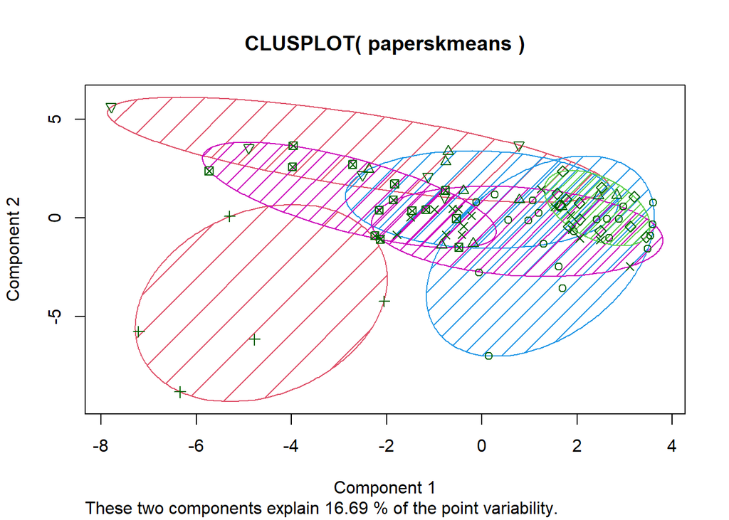

```r
papers3<-papers
papers3$Clusters<-as.factor(clusters$cluster)
clusplot(paperskmeans, paperskmeans$Clusters, color = T, shade = T, labels = 0, lines = 0)
```

#Additional visual exploration made clusters seem like the ideal choice.

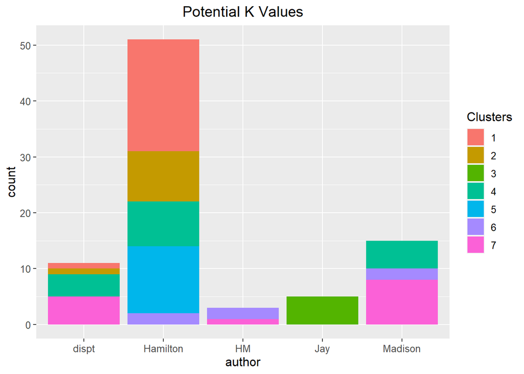

```r
library(ggplot2)
ggplot(data=papers3, aes(x=author, fill=Clusters))+geom_bar(stat='count')+labs(title="Potential K Values")+theme(plot.title=element_text(hjust = 0.5), text=element_text(size=12))
```

```r
FedPapers_HAC <- papers[,c(2:72)]
rownames(FedPapers_HAC) <- FedPapers_HAC[,1]
FedPapers_HAC[,1] <- NULL
```

#Developed various distance formulas between variables using several different methods

```r
distance  <- dist(FedPapers_HAC, method = "euclidean")
distance2 <- dist(FedPapers_HAC, method = "maximum")
distance3 <- dist(FedPapers_HAC, method = "manhattan")
distance4 <- dist(FedPapers_HAC, method = "canberra")
distance5 <- dist(FedPapers_HAC, method = "binary")
```

#Developed Hierarchical Dendograms for each distance method before settling on manhattan measurement

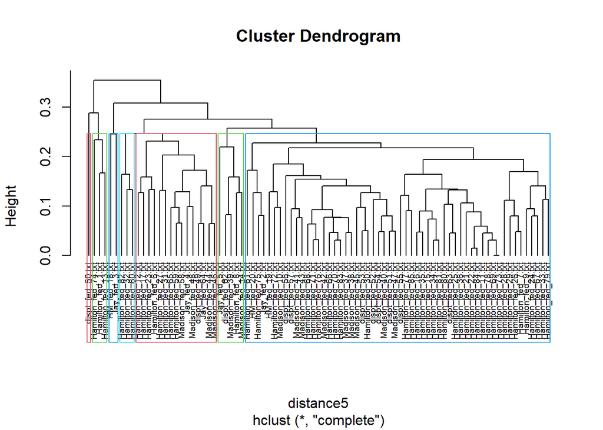

```r
HAC <- hclust(distance5, method="complete")
plot(HAC, cex=0.6, hang=-1)
rect.hclust(HAC, k =7, border=2:5)
```

#Manhattan measurement with a k of 7 provided the most distinct order to the various papers and a patern began to emerge. You’ll note that the disputed papers largely fall in with Madison’s work within the Hierarchy.

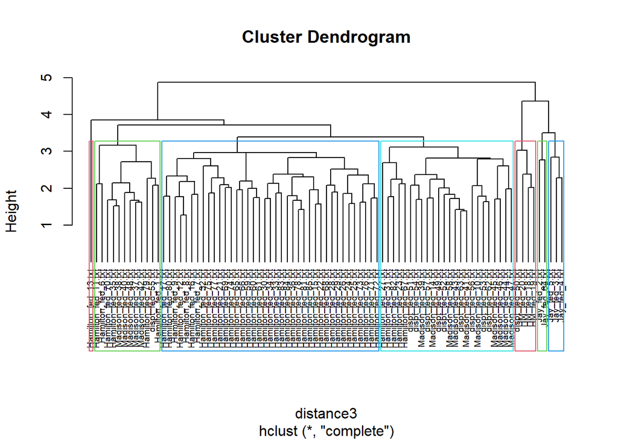

```r
HAC2 <- hclust(distance3, method="complete")
plot(HAC2, cex=0.6, hang=-1)
rect.hclust(HAC2, k =7, border=2:5)
```

#I conducted additional cleaning of the data and separated subsets of the data for visual comparison of where they fell within the clusters.

```r
hc <- hclust(distance3)
cluster <- cutree(hc, k=7)
xy<-data.frame(cmdscale(distance3), factor(cluster))
names(xy) <- c("x", "y", "cluster")
xy$model <- rownames(xy)

#note the split of the data for comparison purposes.
m<-xy[xy$model %like% 'Madison',]
peac<-xy[xy$model %like% 'dispt',]
hamton<-xy[xy$model %like% 'Ham',]
joint<-xy[xy$model %like% 'HM',]

n<-as.data.frame(bind_rows(m,peac))
n<-as.data.frame(bind_rows(n,hamton))
```

#The following charts depict the location of each of the papers produced by Madison, Hamilton, and our mystery writer with relation to one another corresponding with Manhattan Distance with a K of 7.

The first is Madison’s known works.

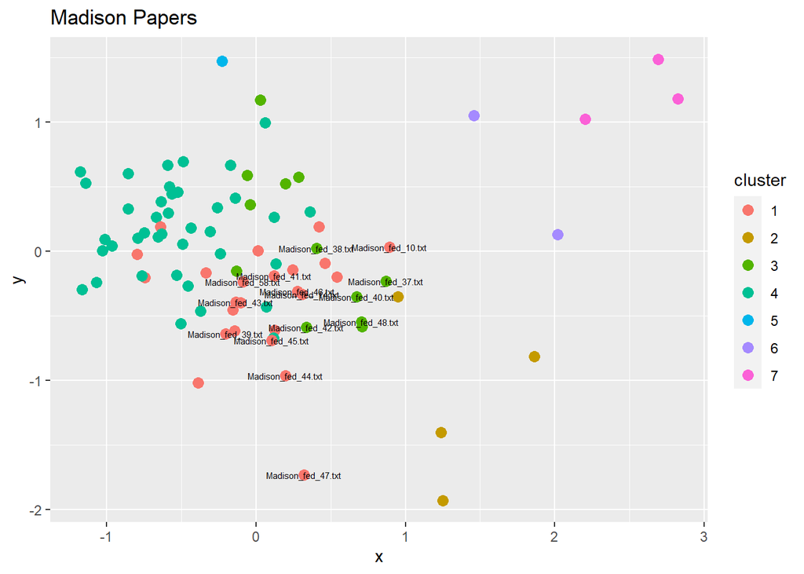

```r
ggplot(xy, aes(x, y)) + geom_point(aes(colour=cluster), size=3)+geom_text(data=m ,aes(label=model), size=2)+ggtitle('Madison Papers')
```

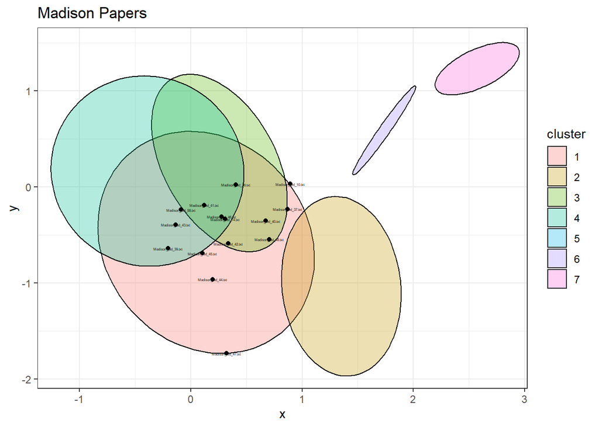

```r
ggplot(xy, aes(x, y)) + geom_mark_ellipse(expand=0,aes(fill=cluster))+geom_point(data=m)+theme_bw()+geom_text(data=m,aes(label=model), size=1)+ggtitle('Madison Papers')
```

The second is our mystery writer

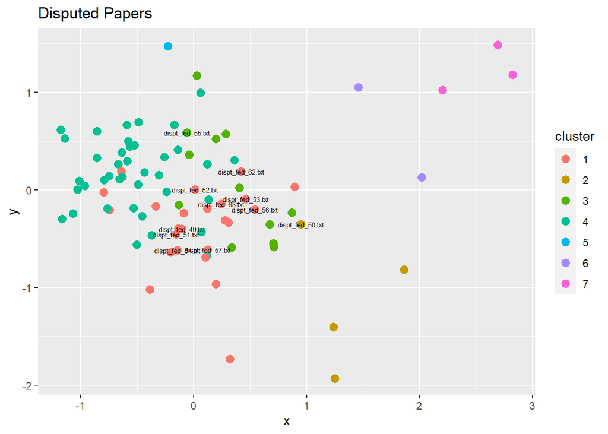

```r
ggplot(xy, aes(x, y)) + geom_point(aes(colour=cluster), size=3)+geom_text(data=peac ,aes(label=model), size=2)+ggtitle('Disputed Papers')
```

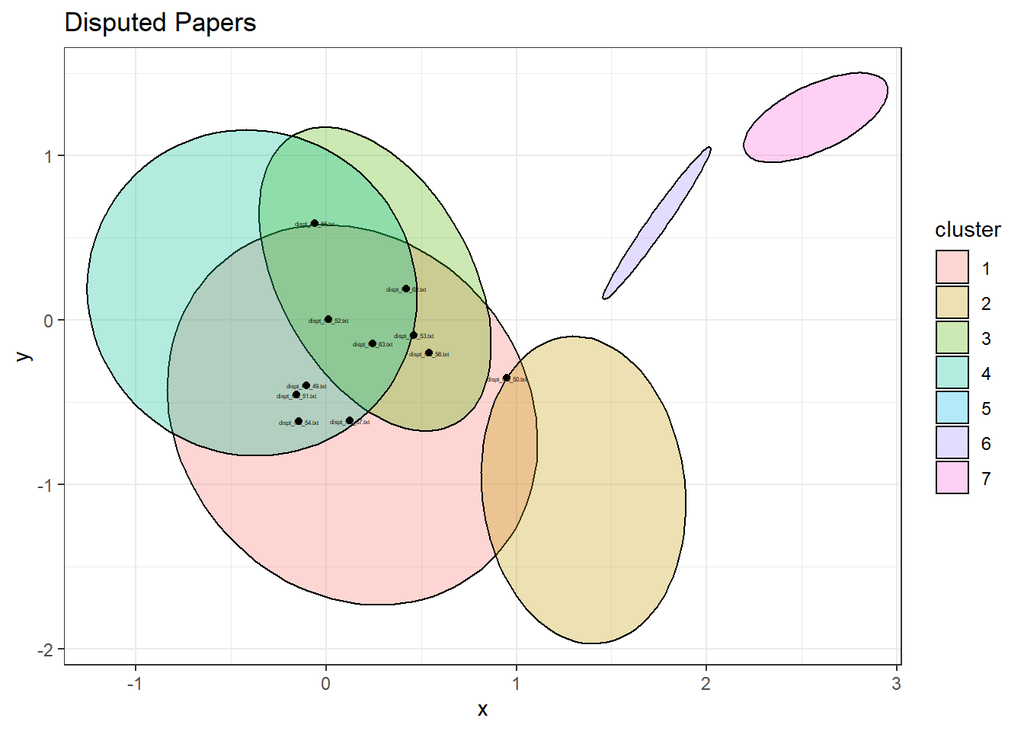

```r
ggplot(xy, aes(x, y)) + geom_mark_ellipse(expand=0,aes(fill=cluster))+geom_point(data=peac)+theme_bw()+geom_text(data=peac,aes(label=model), size=1)+ggtitle('Disputed Papers')
```

The third is Hamilton’s known works

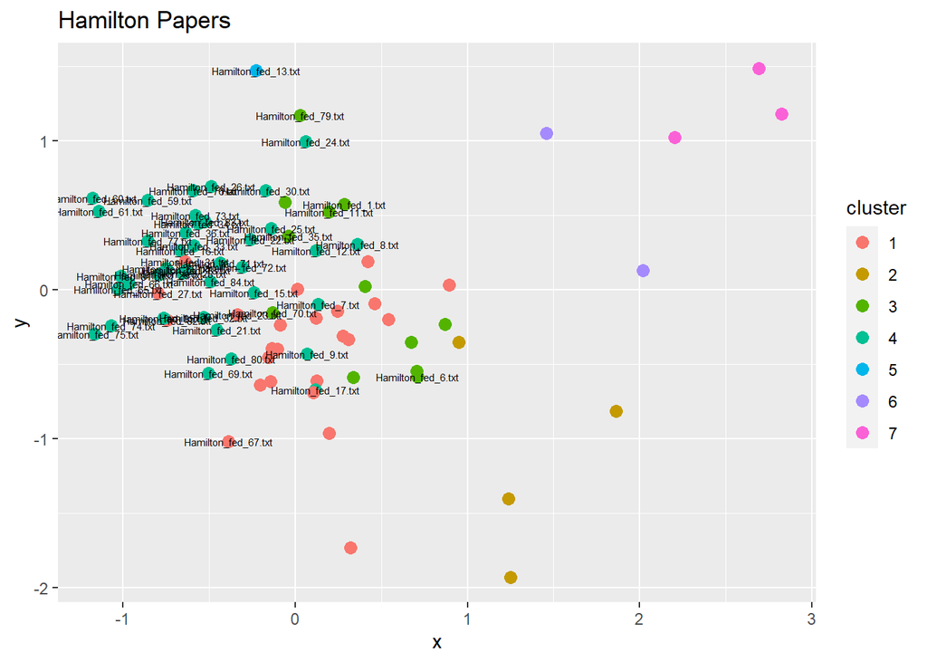

```r
ggplot(xy, aes(x, y)) + geom_point(aes(colour=cluster), size=3)+geom_text(data=hamton ,aes(label=model), size=2)+ggtitle('Hamilton Papers')
```

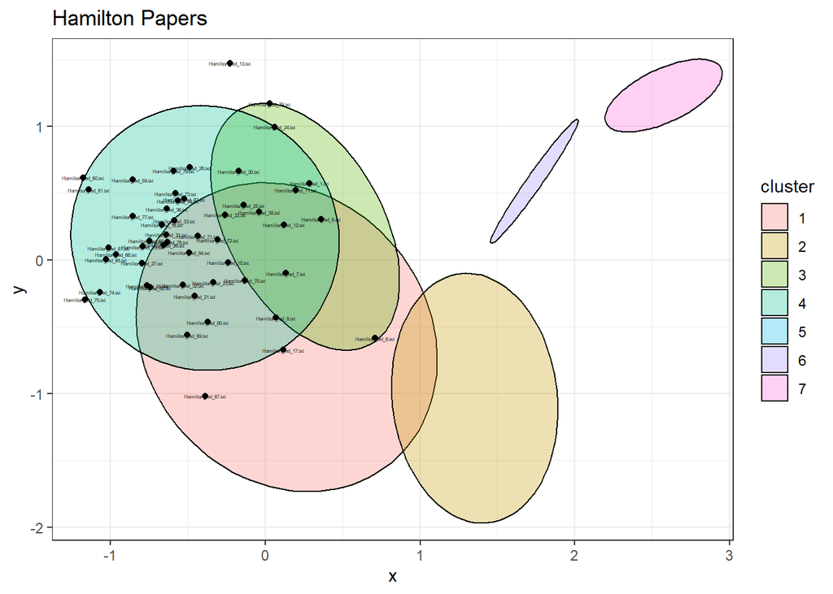

```r
ggplot(xy, aes(x, y)) + geom_mark_ellipse(expand=0,aes(fill=cluster))+geom_point(data=hamton)+theme_bw()+geom_text(data=hamton,aes(label=model), size=1)+ggtitle('Hamilton Papers')
```

I also plotted the location of papers coauthored by both Hamilton and Madison to demonstrate the demonstrable difference such a paper has with relation to others.

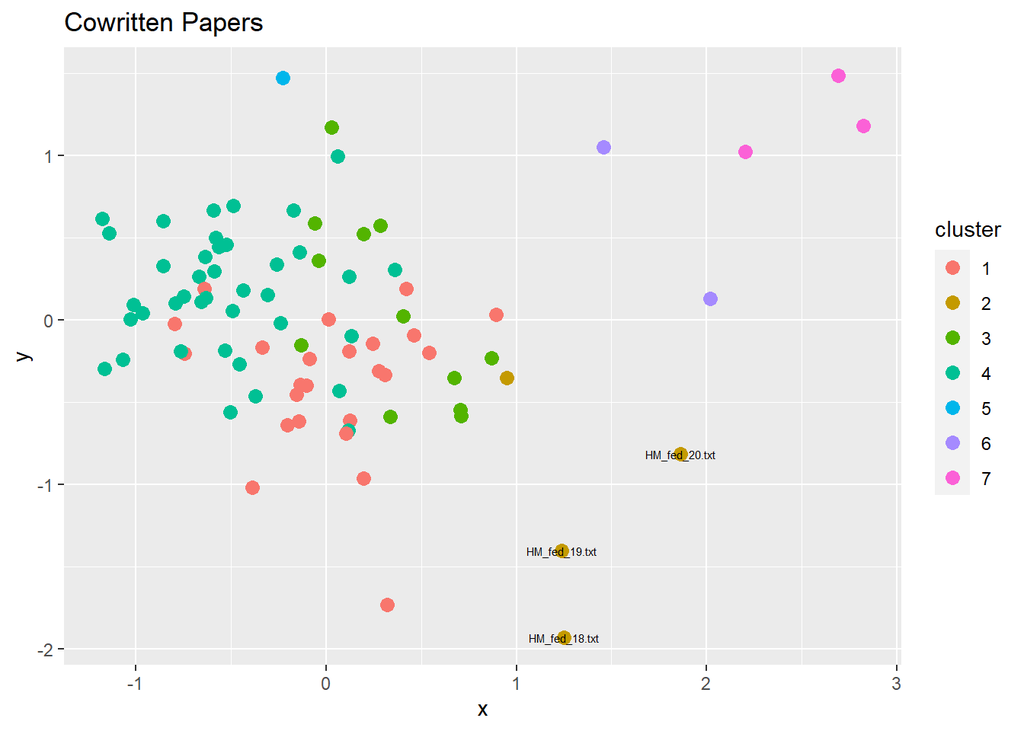

```r
ggplot(xy, aes(x, y)) + geom_point(aes(colour=cluster), size=3)+geom_text(data=joint ,aes(label=model), size=2)+ggtitle('Cowritten Papers')
```

##What I was able to gleen from the various clustering that was conducted on the Federalist Papers was that it is highly likely that the mystery writer for the papers with the unknown author are attributable to Madison. You will note in the plots that while the plots overlap, the majority of Hamilton’s work resides in the upper left of the plot while Madison’s and the mystery author’s works are closer together and occupy more of the middle of the plot. This holds true, not only for the cluster plot but also for the hierarchical dendogram demonstrating a clustering of Madison and the mystery author’s works.